# Positive Vector in Subspace

For the non-negative least squares estimator, it is important to answer the the following question: assume you chose a subspace of dimension $k$ randomly, what is the probability that it will contain a vector $x$ such that $x \ge 0$ (componentwise). More precisily, denote by $S$ an arbitrary $k$ dimensional subspace and choose a random rotation $O \in \mathrm{SO}(d)$ according to the Haar measure, what is $$\mathbb{P}_O(\mathbb{R}^d \cap O S \neq \{0\}).$$ This question can be rephrased more generally as, what is the probability that randomly rotated cones share a common ray.

```python
import ipyparallel
_clients = ipyparallel.Client()
_view = _clients.load_balanced_view()
print("Kernels available: {}".format(len(_clients)))

import sys; sys.path.append("/Users/dsuess/Code/Pythonlibs/")
from tools.helpers import watch_async_view
from scipy.special import binom
```

```
Kernels available: 4
```

### Analytic Solution

A general answer to the problem quoted above is given by the *kinematic formula for cones*: Let $C$ and $K$ be closed convex cones in $\mathbb{R}^d$, one of which is not a subspace. Denote by $O$ a Haar-random rotation matrix, then $$\mathbb{P}_O(C \cap OK \neq \{0\}) = \sum_{i=0}^d (1 + (-1)^{i+1}) \sum_{j=i}^d v_j(C) v_{d + i - j}(K).$$ Here, $v_i(C)$ denotes the $i$th intrinsic volume of the cone $C$. For more info see [1].

Unfortunately, $v_i(C)$ is only known for a few special cases. [1] derives a realy nice approximative kinematic formula for cones that only relies on the Gaussian widths, which are much easier to compute.

Luckily for us, the intrinsic volumes are known for subspaces and the positive octant (see [1, Sec. 5.1}): For $S$ being a $k$ dim subspace we have $$v_i(S) = \delta_{i,k},$$ with the Kronecker delta. On the other hand, we have for the positive octant $$v_i(\mathbb{R}^d) = 2^{-d} {d \choose i}.$$ A simple calculation hence yields: $$\mathbb{P}_O(\mathbb{R}^d \cap O S \neq \{0\}) = 2^{-d + 1} \sum_{i=0}^{\lfloor \frac{d-1}{2} \rfloor} {d \choose d - k + 2i + 1}.$$

```python
def analytic(d, k):
    ii = np.arange((d - 1) // 2 + 1)
    return 2**(-d + 1) * sum(binom(d, d - k + 2*i + 1) for i in ii)
```

### Numerical Experiment

To check the formula numerically, proocede as follows: The problem of determining whether a given subspace contains a positive vector can be formulated as a linear feasability problem $$\mathrm{find}\, x \ge 0 \quad\mathrm{s.t.}\, \langle c_i, x \rangle = 0 \quad (i=0,\ldots,d - k - 1)$$ where the $c_i$ are vectors spanning the orthogonal complement. If we choose the $c_i$ from an isotropic, multivariant Gaussian, these subspaces have the same distribution as $OS$.

The function `test_subspace` checks whether a subspace with given dimension chosen randomly according to this distribution contains a non-negative vector. Note that we add the constraint that all components must be larger than some tolerance for numerical stability. The function `gauss_constraints` samples the contraint vectors.

```python
%%px --local

import numpy as np
import cvxpy as cvx

DIM = 50
SAMPLES = 500

def gauss_constraints(ambient_dim, subspace_dim):
    vs = np.random.randn(ambient_dim - subspace_dim, ambient_dim)
    vs /= np.linalg.norm(vs, axis=0, keepdims=True)
    vs *= np.sign(vs[:, :1])
    return vs

def sign_constraints(ambient_dim, subspace_dim):
    vs = 1. * np.random.randint(2, size=(ambient_dim - subspace_dim, ambient_dim))
    vs -= .5
    vs /= np.linalg.norm(vs, axis=0, keepdims=True)
    vs *= np.sign(vs[:, :1])
    return vs

def test_subspace(ambient_dim, subspace_dim, genf=gauss_constraints, tol=1.):
    x = cvx.Variable(ambient_dim)
    # sample constraint vectors from given distribution
    constraint_vectors = genf(ambient_dim, subspace_dim)

    # subspace constraints
    constraints = [c * x == 0 for c in constraint_vectors]
    # tolerance constraint for stability
    constraints += [x > tol]
    # Solve feasability problem by solving trivial optimization problem
    problem = cvx.Problem(cvx.Maximize(1.0), constraints)
    return np.allclose(problem.solve(), 1.0), constraint_vectors
```

```python
task = _view.map_async(lambda d: [test_subspace(DIM, d) for _ in range(SAMPLES)], range(DIM))
watch_async_view(task)
result_gauss = task.result()
```

```
100% (50 of 50) |#########################| Elapsed Time: 0:04:26 Time: 0:04:26
```

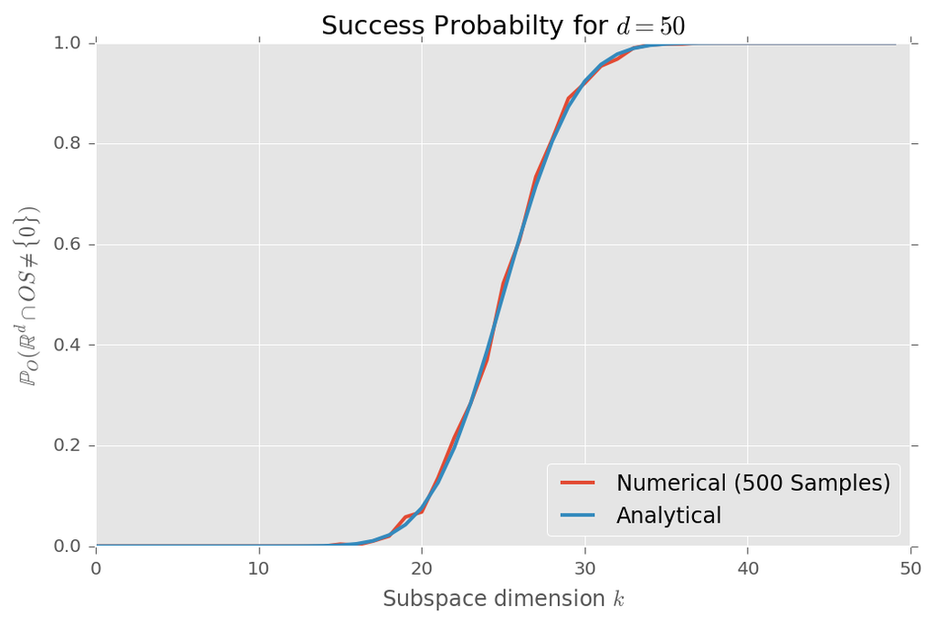

```python
p_success_gauss = [np.sum(success for success, _ in row) / SAMPLES for row in result_gauss]

pl.plot(p_success_gauss, label="Numerical ({} Samples)".format(SAMPLES))
pl.plot([analytic(DIM, k) for k in range(DIM)], label="Analytical")
pl.legend(loc='lower right')

pl.title(r"Success Probabilty for $d=50$")
pl.xlabel(r"Subspace dimension $k$")
pl.ylabel(r"$\mathbb{P}_O(\mathbb{R}^d \cap O S \neq \{0\})$")
```

[1] D. Amelunxen, M. Lotz, M. B. McCoy, and J. A. Tropp, “Living on the edge: phase transitions in convex programs with random data,” Information and Inference, p. iau005, Jun. 2014.